# Project

```
##
## Call:
## lm(formula = production ~ trend + monthFactor + TCDC_middle.cloud.layer_Avg +
##     ma_2 + TMP_surface_Avg + TCDC_middle.cloud.layer_Avg + CSNOW_surface_Avg +
##     DSWRF_Surface_Avg, data = dt)
##
## Residuals:
##     Min      1Q  Median      3Q     Max
## -3.6654 -0.0066  0.0023  0.0104  0.0880
##
## Coefficients:
##                               Estimate Std. Error t value Pr(>|t|)
## (Intercept)                 -2.570e-01  3.507e-01  -0.733   0.4638
## trend                       -2.402e-05  1.946e-05  -1.234   0.2174
## monthFactor02               -4.469e-03  2.030e-02  -0.220   0.8258
## monthFactor03               -9.057e-03  2.370e-02  -0.382   0.7024
## monthFactor04               -1.832e-02  3.070e-02  -0.597   0.5507
## monthFactor05               -6.854e-02  3.278e-02  -2.091   0.0369 *
## monthFactor06               -2.998e-02  3.813e-02  -0.786   0.4320
## monthFactor07               -4.150e-02  4.242e-02  -0.978   0.3282
## monthFactor08               -4.586e-02  4.308e-02  -1.065   0.2874
## monthFactor09               -2.645e-02  3.570e-02  -0.741   0.4590
## monthFactor10               -6.485e-03  2.838e-02  -0.229   0.8193
## monthFactor11                1.002e-03  2.372e-02   0.042   0.9663
## monthFactor12                2.689e-03  2.202e-02   0.122   0.9028
## TCDC_middle.cloud.layer_Avg -1.425e-04  2.795e-04  -0.510   0.6103
## ma_2                         9.950e-01  3.044e-03 326.902   <2e-16 ***
## TMP_surface_Avg              9.183e-04  1.302e-03   0.705   0.4808
## CSNOW_surface_Avg            2.137e-02  3.879e-02   0.551   0.5818
## DSWRF_Surface_Avg            1.768e-04  1.449e-04   1.220   0.2226
## ---
## Signif. codes:  0 '***' 0.001 '**' 0.01 '*' 0.05 '.' 0.1 ' ' 1
##
## Residual standard error: 0.1273 on 854 degrees of freedom
##   (5 observations deleted due to missingness)
## Multiple R-squared:  0.997,  Adjusted R-squared:  0.9969
## F-statistic: 1.662e+04 on 17 and 854 DF,  p-value: < 2.2e-16
```

```
##
## Call:
## lm(formula = production ~ trend + monthFactor + TCDC_middle.cloud.layer_Avg +
##     ma_2 + TMP_surface_Avg + TCDC_middle.cloud.layer_Avg + CSNOW_surface_Avg +
##     DSWRF_Surface_Avg, data = dt)
##
## Residuals:
##     Min      1Q  Median      3Q     Max
## -6.3593 -0.0100  0.0035  0.0185  0.1642
##
## Coefficients:
##                               Estimate Std. Error t value Pr(>|t|)
## (Intercept)                 -4.806e-01  6.082e-01  -0.790   0.4296
## trend                       -4.279e-05  3.322e-05  -1.288   0.1980
## monthFactor02               -6.807e-03  3.519e-02  -0.193   0.8467
## monthFactor03               -1.505e-02  4.111e-02  -0.366   0.7144
## monthFactor04               -4.747e-02  5.306e-02  -0.895   0.3712
## monthFactor05               -1.308e-01  5.660e-02  -2.311   0.0211 *
## monthFactor06               -7.126e-02  6.579e-02  -1.083   0.2790
## monthFactor07               -8.980e-02  7.348e-02  -1.222   0.2220
## monthFactor08               -8.939e-02  7.483e-02  -1.195   0.2325
## monthFactor09               -5.814e-02  6.154e-02  -0.945   0.3451
## monthFactor10               -1.891e-02  4.837e-02  -0.391   0.6960
## monthFactor11               -1.056e-03  4.089e-02  -0.026   0.9794
## monthFactor12                4.827e-03  3.815e-02   0.126   0.8994
## TCDC_middle.cloud.layer_Avg -3.704e-04  4.881e-04  -0.759   0.4482
## ma_2                         9.922e-01  4.135e-03 239.941   <2e-16 ***
## TMP_surface_Avg              1.810e-03  2.261e-03   0.800   0.4237
## CSNOW_surface_Avg            1.860e-02  6.841e-02   0.272   0.7857
## DSWRF_Surface_Avg            3.215e-04  2.490e-04   1.291   0.1970
## ---
## Signif. codes:  0 '***' 0.001 '**' 0.01 '*' 0.05 '.' 0.1 ' ' 1
##
## Residual standard error: 0.2206 on 854 degrees of freedom
##   (5 observations deleted due to missingness)
## Multiple R-squared:  0.9938, Adjusted R-squared:  0.9937
## F-statistic:  8114 on 17 and 854 DF,  p-value: < 2.2e-16
```

```
##
## Call:
## lm(formula = production ~ trend + monthFactor + TCDC_middle.cloud.layer_Avg +
##     ma_2 + TMP_surface_Avg + TCDC_middle.cloud.layer_Avg + CSNOW_surface_Avg +
##     DSWRF_Surface_Avg, data = dt)
##
## Residuals:
##     Min      1Q  Median      3Q     Max
## -4.8573 -0.0082  0.0033  0.0144  0.1203
##
## Coefficients:
##                               Estimate Std. Error t value Pr(>|t|)
## (Intercept)                 -3.867e-01  4.636e-01  -0.834   0.4045
## trend                       -3.697e-05  2.488e-05  -1.486   0.1377
## monthFactor02               -4.298e-03  2.687e-02  -0.160   0.8730
## monthFactor03               -1.727e-02  3.123e-02  -0.553   0.5803
## monthFactor04               -4.571e-02  4.075e-02  -1.122   0.2624
## monthFactor05               -1.099e-01  4.355e-02  -2.523   0.0118 *
## monthFactor06               -6.693e-02  5.057e-02  -1.324   0.1860
## monthFactor07               -8.167e-02  5.645e-02  -1.447   0.1483
## monthFactor08               -8.060e-02  5.754e-02  -1.401   0.1616
## monthFactor09               -5.309e-02  4.701e-02  -1.129   0.2591
## monthFactor10               -2.353e-02  3.662e-02  -0.643   0.5206
## monthFactor11               -4.852e-03  3.108e-02  -0.156   0.8760
## monthFactor12                4.905e-03  2.909e-02   0.169   0.8661
## TCDC_middle.cloud.layer_Avg -2.858e-04  3.746e-04  -0.763   0.4457
## ma_2                         9.946e-01  2.854e-03 348.522   <2e-16 ***
## TMP_surface_Avg              1.498e-03  1.726e-03   0.868   0.3857
## CSNOW_surface_Avg            7.994e-03  5.288e-02   0.151   0.8799
## DSWRF_Surface_Avg            2.603e-04  1.893e-04   1.375   0.1694
## ---
## Signif. codes:  0 '***' 0.001 '**' 0.01 '*' 0.05 '.' 0.1 ' ' 1
##
## Residual standard error: 0.1681 on 854 degrees of freedom
##   (5 observations deleted due to missingness)
## Multiple R-squared:  0.9968, Adjusted R-squared:  0.9967
## F-statistic: 1.549e+04 on 17 and 854 DF,  p-value: < 2.2e-16
```

```
##
## Call:
## lm(formula = production ~ trend + monthFactor + TCDC_middle.cloud.layer_Avg +
##     ma_2 + TMP_surface_Avg + TCDC_middle.cloud.layer_Avg + CSNOW_surface_Avg +
##     DSWRF_Surface_Avg, data = dt)
##
## Residuals:
##     Min      1Q  Median      3Q     Max
## -6.9222 -0.0106  0.0029  0.0190  0.1810
##
## Coefficients:
##                               Estimate Std. Error t value Pr(>|t|)
## (Intercept)                 -5.401e-01  6.599e-01  -0.818  0.41339
## trend                       -5.600e-05  3.536e-05  -1.584  0.11361
## monthFactor02               -8.176e-03  3.824e-02  -0.214  0.83075
## monthFactor03               -3.013e-02  4.449e-02  -0.677  0.49849
## monthFactor04               -7.027e-02  5.837e-02  -1.204  0.22898
## monthFactor05               -1.631e-01  6.263e-02  -2.604  0.00937 **
## monthFactor06               -1.034e-01  7.260e-02  -1.424  0.15468
## monthFactor07               -1.233e-01  8.086e-02  -1.525  0.12768
## monthFactor08               -1.159e-01  8.194e-02  -1.414  0.15761
## monthFactor09               -8.052e-02  6.714e-02  -1.199  0.23070
## monthFactor10               -3.801e-02  5.219e-02  -0.728  0.46662
## monthFactor11               -9.411e-03  4.427e-02  -0.213  0.83171
## monthFactor12                8.962e-03  4.149e-02   0.216  0.82902
## TCDC_middle.cloud.layer_Avg -3.528e-04  5.309e-04  -0.665  0.50650
## ma_2                         9.928e-01  3.854e-03 257.603  < 2e-16 ***
## TMP_surface_Avg              2.102e-03  2.457e-03   0.855  0.39257
## CSNOW_surface_Avg            1.086e-02  7.554e-02   0.144  0.88569
## DSWRF_Surface_Avg            3.810e-04  2.704e-04   1.409  0.15919
## ---
## Signif. codes:  0 '***' 0.001 '**' 0.01 '*' 0.05 '.' 0.1 ' ' 1
##
## Residual standard error: 0.2396 on 854 degrees of freedom
##   (5 observations deleted due to missingness)
## Multiple R-squared:  0.9936, Adjusted R-squared:  0.9935
## F-statistic:  7794 on 17 and 854 DF,  p-value: < 2.2e-16
```

```
##
## Call:
## lm(formula = production ~ trend + monthFactor + TCDC_middle.cloud.layer_Avg +
##     ma_2 + TMP_surface_Avg + TCDC_middle.cloud.layer_Avg + CSNOW_surface_Avg +
##     DSWRF_Surface_Avg, data = dt)
##
## Residuals:
##     Min      1Q  Median      3Q     Max
## -4.5064 -0.0077  0.0021  0.0133  0.1183
##
## Coefficients:
##                               Estimate Std. Error t value Pr(>|t|)
## (Intercept)                 -3.574e-01  4.304e-01  -0.830  0.40649
## trend                       -4.246e-05  2.313e-05  -1.835  0.06681 .
## monthFactor02               -4.256e-03  2.493e-02  -0.171  0.86450
## monthFactor03               -1.952e-02  2.902e-02  -0.673  0.50130
## monthFactor04               -4.699e-02  3.809e-02  -1.233  0.21776
## monthFactor05               -1.125e-01  4.113e-02  -2.734  0.00639 **
## monthFactor06               -7.124e-02  4.755e-02  -1.498  0.13441
## monthFactor07               -8.281e-02  5.281e-02  -1.568  0.11726
## monthFactor08               -7.691e-02  5.345e-02  -1.439  0.15056
## monthFactor09               -5.300e-02  4.379e-02  -1.210  0.22654
## monthFactor10               -2.489e-02  3.403e-02  -0.731  0.46486
## monthFactor11               -5.944e-03  2.886e-02  -0.206  0.83689
## monthFactor12                7.103e-03  2.707e-02   0.262  0.79305
## TCDC_middle.cloud.layer_Avg -2.842e-04  3.471e-04  -0.819  0.41310
## ma_2                         9.943e-01  2.511e-03 395.985  < 2e-16 ***
## TMP_surface_Avg              1.430e-03  1.603e-03   0.892  0.37252
## CSNOW_surface_Avg            4.085e-03  4.897e-02   0.083  0.93354
## DSWRF_Surface_Avg            2.568e-04  1.760e-04   1.459  0.14482
## ---
## Signif. codes:  0 '***' 0.001 '**' 0.01 '*' 0.05 '.' 0.1 ' ' 1
##
## Residual standard error: 0.1562 on 854 degrees of freedom
##   (5 observations deleted due to missingness)
## Multiple R-squared:  0.9973, Adjusted R-squared:  0.9972
## F-statistic: 1.828e+04 on 17 and 854 DF,  p-value: < 2.2e-16
```

```
##
## Call:
## lm(formula = production ~ trend + monthFactor + TCDC_middle.cloud.layer_Avg +
##     ma_2 + TMP_surface_Avg + TCDC_middle.cloud.layer_Avg + CSNOW_surface_Avg +
##     DSWRF_Surface_Avg, data = dt)
##
## Residuals:
##      Min       1Q   Median       3Q      Max
## -2.62659 -0.00499  0.00151  0.00858  0.08095
##
## Coefficients:
##                               Estimate Std. Error t value Pr(>|t|)
## (Intercept)                 -1.452e-01  2.547e-01  -0.570  0.56881
## trend                       -2.727e-05  1.369e-05  -1.991  0.04676 *
## monthFactor02               -2.216e-03  1.477e-02  -0.150  0.88077
## monthFactor03               -7.116e-03  1.720e-02  -0.414  0.67914
## monthFactor04               -2.037e-02  2.246e-02  -0.907  0.36462
## monthFactor05               -6.255e-02  2.415e-02  -2.590  0.00976 **
## monthFactor06               -3.414e-02  2.804e-02  -1.218  0.22365
## monthFactor07               -3.845e-02  3.108e-02  -1.237  0.21647
## monthFactor08               -3.339e-02  3.143e-02  -1.063  0.28830
## monthFactor09               -2.298e-02  2.587e-02  -0.888  0.37455
## monthFactor10               -1.021e-02  2.017e-02  -0.506  0.61294
## monthFactor11               -1.869e-03  1.712e-02  -0.109  0.91308
## monthFactor12                4.740e-03  1.607e-02   0.295  0.76802
## TCDC_middle.cloud.layer_Avg -2.323e-04  2.063e-04  -1.126  0.26058
## ma_2                         9.963e-01  1.534e-03 649.338  < 2e-16 ***
## TMP_surface_Avg              6.283e-04  9.471e-04   0.663  0.50729
## CSNOW_surface_Avg            3.324e-03  2.879e-02   0.115  0.90812
## DSWRF_Surface_Avg            1.302e-04  1.047e-04   1.243  0.21406
## ---
## Signif. codes:  0 '***' 0.001 '**' 0.01 '*' 0.05 '.' 0.1 ' ' 1
##
## Residual standard error: 0.09261 on 854 degrees of freedom
##   (5 observations deleted due to missingness)
## Multiple R-squared:  0.999,  Adjusted R-squared:  0.999
## F-statistic: 5.022e+04 on 17 and 854 DF,  p-value: < 2.2e-16
```

```
##
## Call:
## lm(formula = production ~ trend + monthFactor + TCDC_middle.cloud.layer_Avg +
##     ma_2 + TMP_surface_Avg + TCDC_middle.cloud.layer_Avg + CSNOW_surface_Avg +
##     DSWRF_Surface_Avg, data = dt)
##
## Residuals:
##     Min      1Q  Median      3Q     Max
## -3.9653 -0.0084  0.0033  0.0142  0.1305
##
## Coefficients:
##                               Estimate Std. Error t value Pr(>|t|)
## (Intercept)                 -1.475e-01  4.075e-01  -0.362   0.7174
## trend                       -4.627e-05  2.188e-05  -2.115   0.0347 *
## monthFactor02               -9.043e-05  2.363e-02  -0.004   0.9969
## monthFactor03               -4.759e-03  2.753e-02  -0.173   0.8628
## monthFactor04               -2.263e-02  3.609e-02  -0.627   0.5308
## monthFactor05               -9.237e-02  3.857e-02  -2.395   0.0168 *
## monthFactor06               -3.981e-02  4.486e-02  -0.887   0.3751
## monthFactor07               -4.484e-02  4.976e-02  -0.901   0.3677
## monthFactor08               -3.902e-02  5.035e-02  -0.775   0.4385
## monthFactor09               -2.456e-02  4.138e-02  -0.594   0.5529
## monthFactor10               -1.272e-02  3.229e-02  -0.394   0.6936
## monthFactor11               -5.376e-03  2.742e-02  -0.196   0.8446
## monthFactor12                2.915e-03  2.563e-02   0.114   0.9095
## TCDC_middle.cloud.layer_Avg -5.027e-04  3.325e-04  -1.512   0.1310
## ma_2                         9.940e-01  2.395e-03 415.110   <2e-16 ***
## TMP_surface_Avg              7.280e-04  1.515e-03   0.481   0.6309
## CSNOW_surface_Avg            5.831e-03  4.580e-02   0.127   0.8987
## DSWRF_Surface_Avg            1.560e-04  1.686e-04   0.925   0.3550
## ---
## Signif. codes:  0 '***' 0.001 '**' 0.01 '*' 0.05 '.' 0.1 ' ' 1
##
## Residual standard error: 0.1482 on 854 degrees of freedom
##   (5 observations deleted due to missingness)
## Multiple R-squared:  0.9977, Adjusted R-squared:  0.9977
## F-statistic: 2.201e+04 on 17 and 854 DF,  p-value: < 2.2e-16
```

```
##
## Call:
## lm(formula = production ~ trend + monthFactor + TCDC_middle.cloud.layer_Avg +
##     ma_2 + TMP_surface_Avg + TCDC_middle.cloud.layer_Avg + CSNOW_surface_Avg +
##     DSWRF_Surface_Avg, data = dt)
##
## Residuals:
##     Min      1Q  Median      3Q     Max
## -6.9295 -0.0139  0.0042  0.0227  0.2180
##
## Coefficients:
##                               Estimate Std. Error t value Pr(>|t|)
## (Intercept)                 -3.463e-01  6.693e-01  -0.517   0.6050
## trend                       -6.805e-05  3.592e-05  -1.894   0.0585 .
## monthFactor02               -3.304e-03  3.883e-02  -0.085   0.9322
## monthFactor03               -1.593e-02  4.518e-02  -0.353   0.7244
## monthFactor04               -5.312e-02  5.875e-02  -0.904   0.3662
## monthFactor05               -1.561e-01  6.277e-02  -2.487   0.0131 *
## monthFactor06               -8.780e-02  7.315e-02  -1.200   0.2304
## monthFactor07               -9.451e-02  8.114e-02  -1.165   0.2444
## monthFactor08               -8.389e-02  8.235e-02  -1.019   0.3086
## monthFactor09               -5.754e-02  6.789e-02  -0.848   0.3969
## monthFactor10               -3.561e-02  5.305e-02  -0.671   0.5023
## monthFactor11               -1.237e-02  4.501e-02  -0.275   0.7836
## monthFactor12               -3.534e-03  4.220e-02  -0.084   0.9333
## TCDC_middle.cloud.layer_Avg -6.889e-04  5.479e-04  -1.257   0.2090
## ma_2                         9.890e-01  4.109e-03 240.666   <2e-16 ***
## TMP_surface_Avg              1.464e-03  2.486e-03   0.589   0.5562
## CSNOW_surface_Avg            2.774e-02  7.436e-02   0.373   0.7092
## DSWRF_Surface_Avg            3.890e-04  2.765e-04   1.407   0.1598
## ---
## Signif. codes:  0 '***' 0.001 '**' 0.01 '*' 0.05 '.' 0.1 ' ' 1
##
## Residual standard error: 0.2433 on 854 degrees of freedom
##   (5 observations deleted due to missingness)
## Multiple R-squared:  0.9936, Adjusted R-squared:  0.9935
## F-statistic:  7800 on 17 and 854 DF,  p-value: < 2.2e-16
```

```
##
## Call:
## lm(formula = production ~ trend + monthFactor + TCDC_middle.cloud.layer_Avg +
##     ma_2 + TMP_surface_Avg + TCDC_middle.cloud.layer_Avg + CSNOW_surface_Avg +
##     DSWRF_Surface_Avg, data = dt)
##
## Residuals:
##     Min      1Q  Median      3Q     Max
## -4.9946 -0.0104  0.0025  0.0161  0.1453
##
## Coefficients:
##                               Estimate Std. Error t value Pr(>|t|)
## (Intercept)                 -2.459e-01  4.948e-01  -0.497   0.6193
## trend                       -6.069e-05  2.696e-05  -2.251   0.0246 *
## monthFactor02               -2.139e-04  2.874e-02  -0.007   0.9941
## monthFactor03               -4.168e-03  3.344e-02  -0.125   0.9008
## monthFactor04               -1.903e-02  4.321e-02  -0.440   0.6597
## monthFactor05               -9.754e-02  4.614e-02  -2.114   0.0348 *
## monthFactor06               -4.025e-02  5.369e-02  -0.750   0.4537
## monthFactor07               -4.752e-02  5.984e-02  -0.794   0.4274
## monthFactor08               -4.109e-02  6.085e-02  -0.675   0.4997
## monthFactor09               -3.139e-02  5.019e-02  -0.625   0.5319
## monthFactor10               -2.267e-02  3.932e-02  -0.577   0.5643
## monthFactor11               -1.013e-02  3.342e-02  -0.303   0.7618
## monthFactor12               -4.135e-03  3.134e-02  -0.132   0.8951
## TCDC_middle.cloud.layer_Avg -5.196e-04  4.053e-04  -1.282   0.2002
## ma_2                         9.928e-01  3.652e-03 271.878   <2e-16 ***
## TMP_surface_Avg              1.027e-03  1.839e-03   0.558   0.5768
## CSNOW_surface_Avg            2.939e-02  5.475e-02   0.537   0.5916
## DSWRF_Surface_Avg            1.944e-04  2.043e-04   0.951   0.3417
## ---
## Signif. codes:  0 '***' 0.001 '**' 0.01 '*' 0.05 '.' 0.1 ' ' 1
##
## Residual standard error: 0.1799 on 854 degrees of freedom
##   (5 observations deleted due to missingness)
## Multiple R-squared:  0.996,  Adjusted R-squared:  0.9959
## F-statistic: 1.256e+04 on 17 and 854 DF,  p-value: < 2.2e-16
```

```
##
## Call:
## lm(formula = production ~ trend + monthFactor + TCDC_middle.cloud.layer_Avg +
##     ma_2 + TMP_surface_Avg + TCDC_middle.cloud.layer_Avg + CSNOW_surface_Avg +
##     DSWRF_Surface_Avg, data = dt)
##
## Residuals:
##      Min       1Q   Median       3Q      Max
## -3.05631 -0.00565  0.00113  0.00801  0.07699
##
## Coefficients:
##                               Estimate Std. Error t value Pr(>|t|)
## (Intercept)                 -2.101e-01  2.939e-01  -0.715   0.4747
## trend                       -3.075e-05  1.627e-05  -1.890   0.0591 .
## monthFactor02               -3.237e-03  1.697e-02  -0.191   0.8487
## monthFactor03               -8.891e-03  1.973e-02  -0.451   0.6523
## monthFactor04               -1.716e-02  2.555e-02  -0.672   0.5019
## monthFactor05               -5.939e-02  2.729e-02  -2.176   0.0298 *
## monthFactor06               -2.959e-02  3.163e-02  -0.936   0.3497
## monthFactor07               -3.649e-02  3.532e-02  -1.033   0.3019
## monthFactor08               -3.377e-02  3.599e-02  -0.938   0.3483
## monthFactor09               -2.660e-02  2.962e-02  -0.898   0.3695
## monthFactor10               -1.531e-02  2.323e-02  -0.659   0.5100
## monthFactor11               -4.262e-03  1.966e-02  -0.217   0.8284
## monthFactor12                1.728e-03  1.837e-02   0.094   0.9251
## TCDC_middle.cloud.layer_Avg -1.520e-04  2.339e-04  -0.650   0.5161
## ma_2                         9.980e-01  2.540e-03 392.962   <2e-16 ***
## TMP_surface_Avg              7.838e-04  1.092e-03   0.718   0.4730
## CSNOW_surface_Avg            2.257e-02  3.236e-02   0.698   0.4856
## DSWRF_Surface_Avg            1.052e-04  1.182e-04   0.889   0.3740
## ---
## Signif. codes:  0 '***' 0.001 '**' 0.01 '*' 0.05 '.' 0.1 ' ' 1
##
## Residual standard error: 0.1062 on 854 degrees of freedom
##   (5 observations deleted due to missingness)
## Multiple R-squared:  0.9979, Adjusted R-squared:  0.9979
## F-statistic: 2.422e+04 on 17 and 854 DF,  p-value: < 2.2e-16
```

```
##
## Call:
## lm(formula = production ~ trend + monthFactor + TCDC_middle.cloud.layer_Avg +
##     ma_2 + TMP_surface_Avg + TCDC_middle.cloud.layer_Avg + CSNOW_surface_Avg +
##     DSWRF_Surface_Avg, data = dt)
##
## Residuals:
##      Min       1Q   Median       3Q      Max
## -0.95081 -0.00176  0.00036  0.00240  0.02344
##
## Coefficients:
##                               Estimate Std. Error t value Pr(>|t|)
## (Intercept)                 -5.727e-02  9.164e-02  -0.625   0.5322
## trend                       -8.717e-06  5.249e-06  -1.661   0.0971 .
## monthFactor02               -1.280e-03  5.269e-03  -0.243   0.8081
## monthFactor03               -2.881e-03  6.136e-03  -0.470   0.6388
## monthFactor04               -5.525e-03  7.987e-03  -0.692   0.4893
## monthFactor05               -1.879e-02  8.566e-03  -2.194   0.0285 *
## monthFactor06               -9.002e-03  9.874e-03  -0.912   0.3622
## monthFactor07               -1.139e-02  1.101e-02  -1.034   0.3014
## monthFactor08               -1.083e-02  1.125e-02  -0.963   0.3357
## monthFactor09               -8.144e-03  9.227e-03  -0.883   0.3777
## monthFactor10               -4.185e-03  7.228e-03  -0.579   0.5627
## monthFactor11               -1.003e-03  6.110e-03  -0.164   0.8697
## monthFactor12                6.903e-04  5.718e-03   0.121   0.9039
## TCDC_middle.cloud.layer_Avg -4.371e-05  7.269e-05  -0.601   0.5478
## ma_2                         9.999e-01  1.248e-03 801.147   <2e-16 ***
## TMP_surface_Avg              2.147e-04  3.407e-04   0.630   0.5288
## CSNOW_surface_Avg            6.533e-03  1.007e-02   0.649   0.5168
## DSWRF_Surface_Avg            2.508e-05  3.583e-05   0.700   0.4840
## ---
## Signif. codes:  0 '***' 0.001 '**' 0.01 '*' 0.05 '.' 0.1 ' ' 1
##
## Residual standard error: 0.03305 on 854 degrees of freedom
##   (5 observations deleted due to missingness)
## Multiple R-squared:  0.9994, Adjusted R-squared:  0.9994
## F-statistic: 8.063e+04 on 17 and 854 DF,  p-value: < 2.2e-16
```

```
##
## Call:
## lm(formula = production ~ trend + monthFactor + TCDC_middle.cloud.layer_Avg +
##     ma_2 + TMP_surface_Avg + TCDC_middle.cloud.layer_Avg + CSNOW_surface_Avg +
##     DSWRF_Surface_Avg, data = dt)
##
## Residuals:
##       Min        1Q    Median        3Q       Max
## -0.078662 -0.000129  0.000016  0.000181  0.010817
##
## Coefficients:
##                               Estimate Std. Error  t value Pr(>|t|)
## (Intercept)                 -6.054e-03  7.532e-03   -0.804   0.4218
## trend                       -5.686e-07  4.043e-07   -1.407   0.1599
## monthFactor02               -1.638e-04  4.364e-04   -0.375   0.7075
## monthFactor03               -4.007e-04  5.083e-04   -0.788   0.4307
## monthFactor04               -7.236e-04  6.575e-04   -1.100   0.2715
## monthFactor05               -1.619e-03  7.026e-04   -2.305   0.0214 *
## monthFactor06               -1.043e-03  8.188e-04   -1.274   0.2029
## monthFactor07               -1.274e-03  9.168e-04   -1.390   0.1649
## monthFactor08               -1.214e-03  9.288e-04   -1.307   0.1915
## monthFactor09               -8.979e-04  7.641e-04   -1.175   0.2402
## monthFactor10               -4.643e-04  5.963e-04   -0.779   0.4364
## monthFactor11               -1.200e-04  5.060e-04   -0.237   0.8125
## monthFactor12                6.271e-05  4.736e-04    0.132   0.8947
## TCDC_middle.cloud.layer_Avg -1.199e-06  6.009e-06   -0.200   0.8419
## ma_2                         1.000e+00  3.489e-04 2866.468   <2e-16 ***
## TMP_surface_Avg              2.155e-05  2.799e-05    0.770   0.4416
## CSNOW_surface_Avg            5.501e-04  8.327e-04    0.661   0.5091
## DSWRF_Surface_Avg            3.347e-06  2.959e-06    1.131   0.2583
## ---
## Signif. codes:  0 '***' 0.001 '**' 0.01 '*' 0.05 '.' 0.1 ' ' 1
##
## Residual standard error: 0.002738 on 854 degrees of freedom
##   (5 observations deleted due to missingness)
## Multiple R-squared:  0.9999, Adjusted R-squared:  0.9999
## F-statistic: 5.797e+05 on 17 and 854 DF,  p-value: < 2.2e-16
```

```
##
## Call:
## lm(formula = production ~ trend + monthFactor + TCDC_middle.cloud.layer_Avg +
##     ma_2 + TMP_surface_Avg + TCDC_middle.cloud.layer_Avg + CSNOW_surface_Avg +
##     DSWRF_Surface_Avg, data = dt)
##
## Residuals:
##        Min         1Q     Median         3Q        Max
## -9.472e-17 -1.140e-19  3.000e-20  1.980e-19  5.273e-18
##
## Coefficients:
##                               Estimate Std. Error    t value Pr(>|t|)
## (Intercept)                 -8.578e-18  9.060e-18 -9.470e-01   0.3440
## trend                        2.321e-22  4.853e-22  4.780e-01   0.6326
## monthFactor02                3.150e-20  5.243e-19  6.000e-02   0.9521
## monthFactor03               -2.662e-19  6.127e-19 -4.340e-01   0.6641
## monthFactor04               -6.069e-19  7.951e-19 -7.630e-01   0.4455
## monthFactor05               -6.670e-19  8.497e-19 -7.850e-01   0.4327
## monthFactor06               -2.054e-19  9.899e-19 -2.070e-01   0.8357
## monthFactor07                1.396e-18  1.115e-18  1.252e+00   0.2109
## monthFactor08               -6.983e-19  1.121e-18 -6.230e-01   0.5335
## monthFactor09               -5.048e-19  9.232e-19 -5.470e-01   0.5846
## monthFactor10               -4.053e-19  7.177e-19 -5.650e-01   0.5724
## monthFactor11               -2.337e-19  6.074e-19 -3.850e-01   0.7006
## monthFactor12               -6.327e-20  5.684e-19 -1.110e-01   0.9114
## TCDC_middle.cloud.layer_Avg  1.641e-20  7.212e-21  2.275e+00   0.0231 *
## ma_2                         1.000e+00  1.022e-16  9.787e+15   <2e-16 ***
## TMP_surface_Avg              2.925e-20  3.365e-20  8.690e-01   0.3850
## CSNOW_surface_Avg           -1.230e-18  1.001e-18 -1.228e+00   0.2197
## DSWRF_Surface_Avg            9.295e-22  3.584e-21  2.590e-01   0.7954
## ---
## Signif. codes:  0 '***' 0.001 '**' 0.01 '*' 0.05 '.' 0.1 ' ' 1
##
## Residual standard error: 3.286e-18 on 854 degrees of freedom
##   (5 observations deleted due to missingness)
## Multiple R-squared:      1,  Adjusted R-squared:      1
## F-statistic: 5.978e+30 on 17 and 854 DF,  p-value: < 2.2e-16
```

```
##
## Call:
## lm(formula = production ~ trend + monthFactor + TCDC_middle.cloud.layer_Avg +
##     ma_2 + TMP_surface_Avg + TCDC_middle.cloud.layer_Avg + CSNOW_surface_Avg +
##     DSWRF_Surface_Avg, data = dt)
##
## Residuals:
##    Min     1Q Median     3Q    Max
##      0      0      0      0      0
##
## Coefficients: (1 not defined because of singularities)
##                             Estimate Std. Error t value Pr(>|t|)
## (Intercept)                        0          0     NaN      NaN
## trend                              0          0     NaN      NaN
## monthFactor02                      0          0     NaN      NaN
## monthFactor03                      0          0     NaN      NaN
## monthFactor04                      0          0     NaN      NaN
## monthFactor05                      0          0     NaN      NaN
## monthFactor06                      0          0     NaN      NaN
## monthFactor07                      0          0     NaN      NaN
## monthFactor08                      0          0     NaN      NaN
## monthFactor09                      0          0     NaN      NaN
## monthFactor10                      0          0     NaN      NaN
## monthFactor11                      0          0     NaN      NaN
## monthFactor12                      0          0     NaN      NaN
## TCDC_middle.cloud.layer_Avg        0          0     NaN      NaN
## ma_2                              NA         NA      NA       NA
## TMP_surface_Avg                    0          0     NaN      NaN
## CSNOW_surface_Avg                  0          0     NaN      NaN
## DSWRF_Surface_Avg                  0          0     NaN      NaN
##
## Residual standard error: 0 on 855 degrees of freedom
##   (5 observations deleted due to missingness)
## Multiple R-squared:    NaN,  Adjusted R-squared:    NaN
## F-statistic:   NaN on 16 and 855 DF,  p-value: NA
```

The code performs regression analysis on hourly production data, extracting columns for hours 5 to 20 from prod_weather and renaming them to ‘production’. It then iterates through each hourly dataset, adding month and trend factors, calculating a moving average, and fitting a linear regression model using production and various weather predictors. The model summaries and predictions are stored for each hour, enhancing the understanding of production variations specific to different times of the day. This detailed hourly analysis improves prediction accuracy and provides valuable insights for operational decision-making.

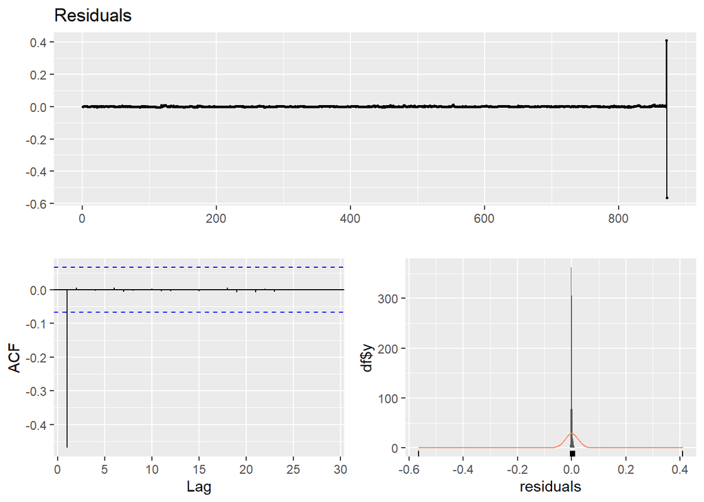

```
##
##  Ljung-Box test
##
## data:  Residuals
## Q* = 192.86, df = 10, p-value < 2.2e-16
##
## Model df: 0.   Total lags used: 10
```

[figure not shown]

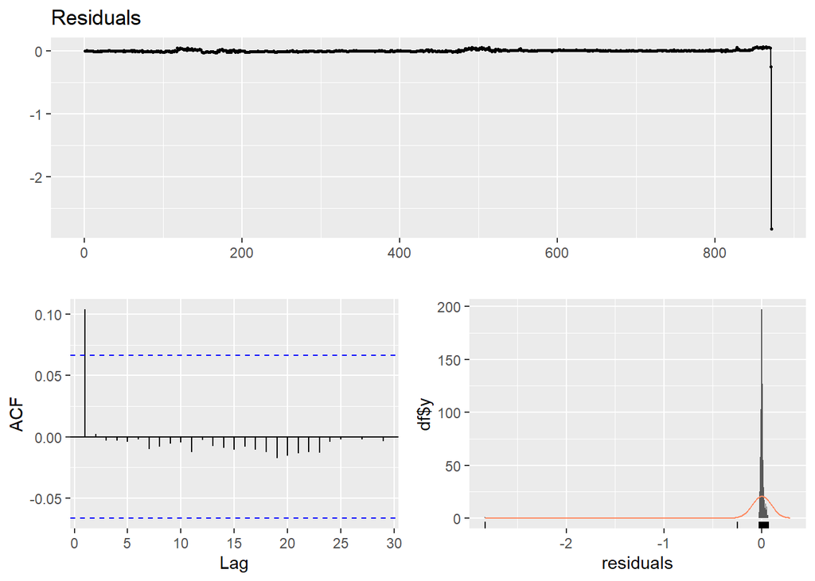

```
##
##  Ljung-Box test
##
## data:  Residuals
## Q* = 9.6594, df = 10, p-value = 0.4709
##
## Model df: 0.   Total lags used: 10
```

[figure not shown]

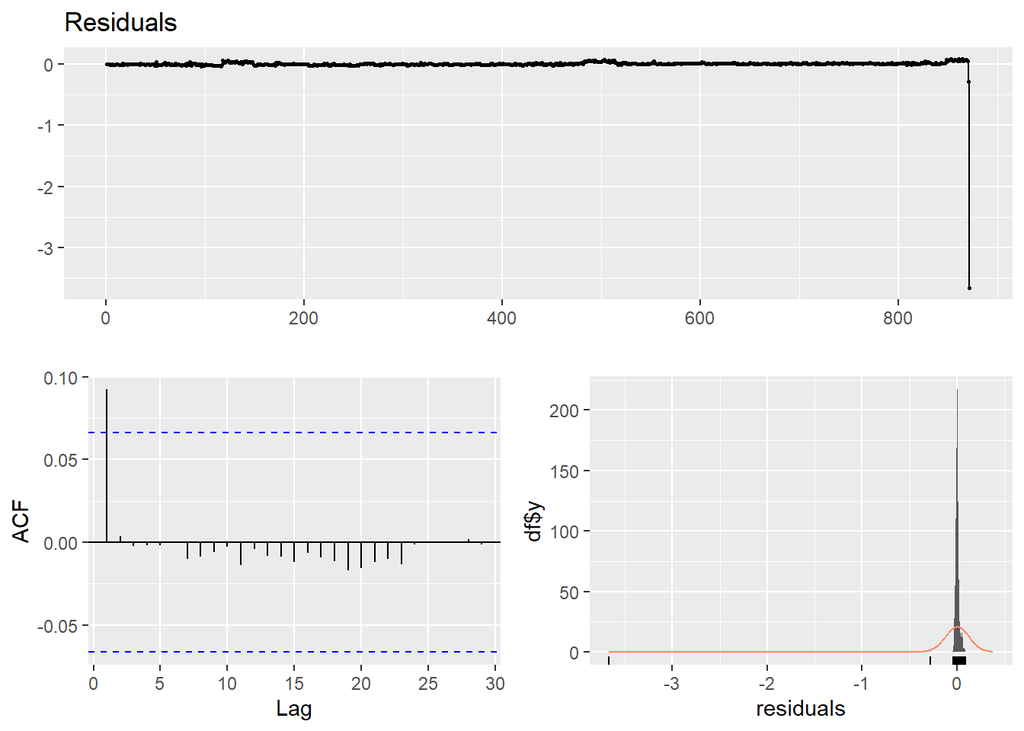

```
##
##  Ljung-Box test
##
## data:  Residuals
## Q* = 7.6686, df = 10, p-value = 0.6612
##
## Model df: 0.   Total lags used: 10
```

[figure not shown]

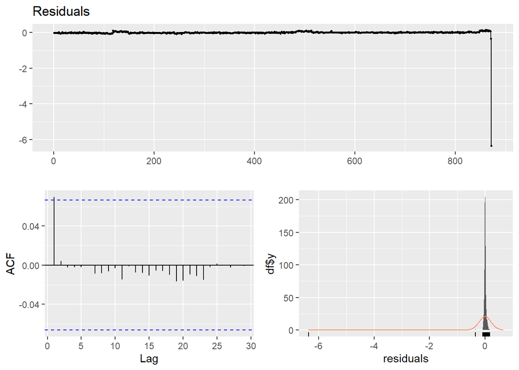

```
##
##  Ljung-Box test
##
## data:  Residuals
## Q* = 4.4351, df = 10, p-value = 0.9256
##
## Model df: 0.   Total lags used: 10
```

[figure not shown]

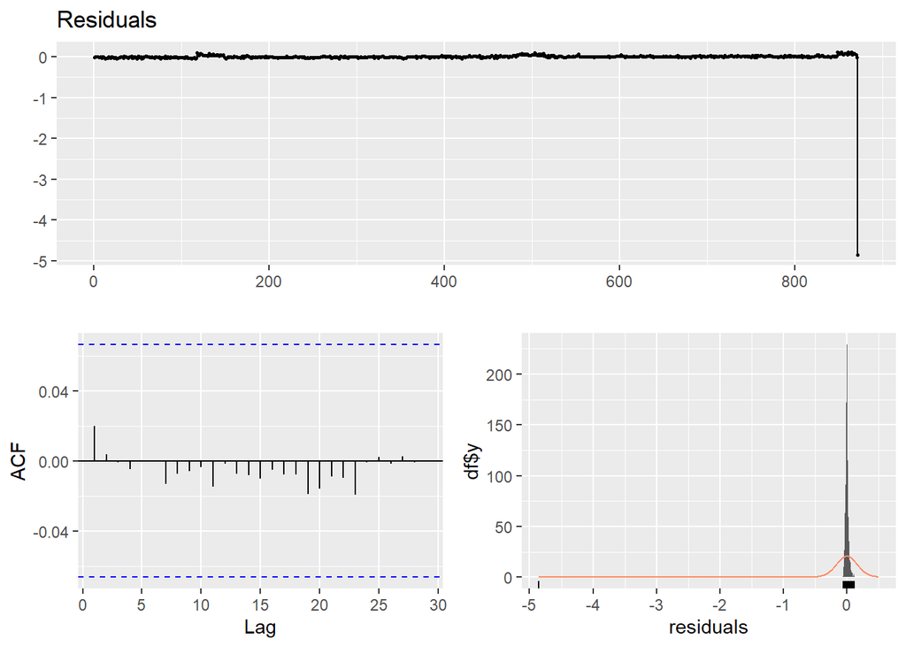

```
##
##  Ljung-Box test
##
## data:  Residuals
## Q* = 0.63219, df = 10, p-value = 1
##
## Model df: 0.   Total lags used: 10
```

[figure not shown]

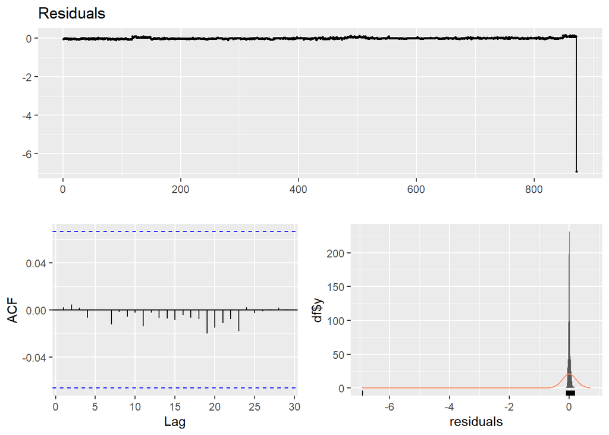

```
##
##  Ljung-Box test
##
## data:  Residuals
## Q* = 0.23496, df = 10, p-value = 1
##
## Model df: 0.   Total lags used: 10
```

[figure not shown]

[20 more figures not shown]

```r
for (j in 1:16) {
  checkresiduals(hourly_models[[j]]$residuals)
  plotting_res = data.frame(Residuals = hourly_models[[j]]$residuals,
                            Fitted_values = prod$hourly_prediction[prod$hour == j + 4][1:872])
  print(ggplot(plotting_res, aes(x = Fitted_values, y = Residuals)) +
    geom_point() +
    ggtitle(paste("CheckResidual Result for ", j + 4, ".00", sep = "")) +
    geom_smooth(method = "lm", se = FALSE))
}
```